# Feederwatch: FL State Report

Jaxine Wolfe

19 August 2025

[Project FeederWatch](https://feederwatch.org/explore/raw-dataset-requests/) is a November-April survey of birds that visit backyards, nature centers, community areas, and other locales in North America. Participatory scientists count birds in areas with plantings, habitat, water, or food that attracts birds. The schedule is completely flexible. People count birds as long as they like on days of their choosing, then enter their counts online. This allows anyone to track what is happening to birds around your home and to contribute to a continental data-set of bird distribution and abundance. Project FeederWatch is operated by the Cornell Lab of Ornithology and Birds Canada.

The data used in this report is from one Feederwatch survey which was posted for [Tidy Tuesday](https://github.com/rfordatascience/tidytuesday/tree/main/data/2023/2023-01-10). The observations for this survey were taken between 2020-11-13 and 2021-04-30.

## Data Summary

|  | Common Name | Scientific Name | Count |
| --- | --- | --- | --- |
| 1 | Chipping Sparrow | Spizella passerina | 450 |
| 2 | Mourning Dove | Zenaida macroura | 415 |
| 3 | Northern Cardinal | Cardinalis cardinalis | 308 |
| 4 | American Goldfinch | Spinus tristis | 218 |
| 5 | Common Grackle | Quiscalus quiscula | 198 |
| 6 | Painted Bunting | Passerina ciris | 170 |
| 7 | Blue Jay | Cyanocitta cristata | 165 |
| 8 | Black-bellied Whistling-Duck | Dendrocygna autumnalis | 148 |
| 9 | American Crow | Corvus brachyrhynchos | 110 |
| 10 | Tufted Titmouse | Baeolophus bicolor | 106 |

[output cut: 79 more lines]

## Data Visualization

### Bird Counts

Plotting bird counts for each species observed and arranging in visually descending order.

[interactive chart not shown]

### Observations Over Time

Let’s make a heatmap of observations by species and month.

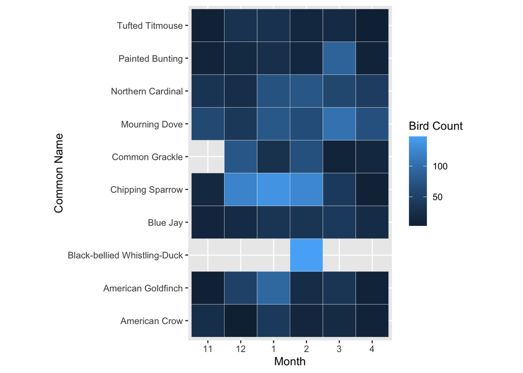

Animation of the top 10 observed species through time. Observations are represented as a cumulative sum.

[figure not shown]

## Mapping With Leaflet

Map of all the bird observations in this state for the study duration. The radius of each point indicates the relative number of individuals observed for a given species.

[interactive chart not shown]

Let’s add some color and look at the top observed species for this state.

[interactive chart not shown]